# EasyVisa_Full_Code2

## Problem Statement

### Business Context

Business communities in the United States are facing high demand for human resources, but one of the constant challenges is identifying and attracting the right talent, which is perhaps the most important element in remaining competitive. Companies in the United States look for hard-working, talented, and qualified individuals both locally as well as abroad.

The Immigration and Nationality Act (INA) of the US permits foreign workers to come to the United States to work on either a temporary or permanent basis. The act also protects US workers against adverse impacts on their wages or working conditions by ensuring US employers' compliance with statutory requirements when they hire foreign workers to fill workforce shortages. The immigration programs are administered by the Office of Foreign Labor Certification (OFLC).

OFLC processes job certification applications for employers seeking to bring foreign workers into the United States and grants certifications in those cases where employers can demonstrate that there are not sufficient US workers available to perform the work at wages that meet or exceed the wage paid for the occupation in the area of intended employment.

### Objective

In FY 2016, the OFLC processed 775,979 employer applications for 1,699,957 positions for temporary and permanent labor certifications. This was a nine percent increase in the overall number of processed applications from the previous year. The process of reviewing every case is becoming a tedious task as the number of applicants is increasing every year.

The increasing number of applicants every year calls for a Machine Learning based solution that can help in shortlisting the candidates having higher chances of VISA approval. OFLC has hired the firm EasyVisa for data-driven solutions. You as a data scientist at EasyVisa have to analyze the data provided and, with the help of a classification model:

- Facilitate the process of visa approvals.
- Recommend a suitable profile for the applicants for whom the visa should be certified or denied based on the drivers that significantly influence the case status.

### Data Description

The data contains the different attributes of employee and the employer. The detailed data dictionary is given below.

- case_id: ID of each visa application
- continent: Information of continent the employee
- education_of_employee: Information of education of the employee
- has_job_experience: Does the employee has any job experience? Y= Yes; N = No
- requires_job_training: Does the employee require any job training? Y = Yes; N = No
- no_of_employees: Number of employees in the employer's company
- yr_of_estab: Year in which the employer's company was established
- region_of_employment: Information of foreign worker's intended region of employment in the US.
- prevailing_wage: Average wage paid to similarly employed workers in a specific occupation in the area of intended employment. The purpose of the prevailing wage is to ensure that the foreign worker is not underpaid compared to other workers offering the same or similar service in the same area of employment.
- unit_of_wage: Unit of prevailing wage. Values include Hourly, Weekly, Monthly, and Yearly.
- full_time_position: Is the position of work full-time? Y = Full Time Position; N = Part Time Position
- case_status: Flag indicating if the Visa was certified or denied

## Installing and Importing the necessary libraries

```python
!pip install numpy pandas scikit-learn matplotlib seaborn xgboost -q --user
```

[output not shown]

```python
# Install XGBoost separately
!pip install xgboost --user
```

[output not shown]

**Note**: *After running the above cell, kindly restart the notebook kernel and run all cells sequentially from the below.*

```python
# Importing all necessary libraries
import numpy as np
import pandas as pd
import matplotlib.pyplot as plt
import seaborn as sns

# Machine Learning Libraries
from sklearn.model_selection import train_test_split, cross_val_score, GridSearchCV
from sklearn.preprocessing import StandardScaler, OneHotEncoder
from sklearn.compose import ColumnTransformer
from sklearn.pipeline import Pipeline
from sklearn.metrics import accuracy_score, precision_score, recall_score, f1_score, confusion_matrix, classification_report, roc_auc_score, roc_curve

# Classification Models
from sklearn.tree import DecisionTreeClassifier
from sklearn.ensemble import RandomForestClassifier, BaggingClassifier, AdaBoostClassifier, GradientBoostingClassifier

# Try to import XGBoost (optional as mentioned in the notebook)
try:
    import xgboost as xgb
    XGBOOST_AVAILABLE = True
    print("XGBoost is available")
except ImportError:
    print("XGBoost not available - skipping as mentioned in notebook instructions")
    XGBOOST_AVAILABLE = False

import warnings
warnings.filterwarnings('ignore')

# Set plotting style
plt.style.use('ggplot')
sns.set_style('whitegrid')

print("All libraries imported successfully!")
```

```
XGBoost is available
All libraries imported successfully!
```

## Import Dataset

```python
# Load the dataset
df = pd.read_csv('EasyVisa.csv')
print("Dataset loaded successfully!")
print(f"Dataset shape: {df.shape}")
```

```
Dataset loaded successfully!
Dataset shape: (25480, 12)
```

## Overview of the Dataset

#### View the first and last 5 rows of the dataset

```python
# Display first 5 rows
print("First 5 rows of the dataset:")
display(df.head())

print("Last 5 rows of the dataset:")
display(df.tail())
```

```
First 5 rows of the dataset:
```

|  | case_id | continent | education_of_employee | has_job_experience | requires_job_training | no_of_employees | yr_of_estab | region_of_employment | prevailing_wage | unit_of_wage | full_time_position | case_status |
| --- | --- | --- | --- | --- | --- | --- | --- | --- | --- | --- | --- | --- |
| 0 | EZYV01 | Asia | High School | N | N | 14513 | 2007 | West | 592.2029 | Hour | Y | Denied |
| 1 | EZYV02 | Asia | Master's | Y | N | 2412 | 2002 | Northeast | 83425.6500 | Year | Y | Certified |
| 2 | EZYV03 | Asia | Bachelor's | N | Y | 44444 | 2008 | West | 122996.8600 | Year | Y | Denied |
| 3 | EZYV04 | Asia | Bachelor's | N | N | 98 | 1897 | West | 83434.0300 | Year | Y | Denied |
| 4 | EZYV05 | Africa | Master's | Y | N | 1082 | 2005 | South | 149907.3900 | Year | Y | Certified |

```
Last 5 rows of the dataset:
```

|  | case_id | continent | education_of_employee | has_job_experience | requires_job_training | no_of_employees | yr_of_estab | region_of_employment | prevailing_wage | unit_of_wage | full_time_position | case_status |
| --- | --- | --- | --- | --- | --- | --- | --- | --- | --- | --- | --- | --- |
| 25475 | EZYV25476 | Asia | Bachelor's | Y | Y | 2601 | 2008 | South | 77092.57 | Year | Y | Certified |
| 25476 | EZYV25477 | Asia | High School | Y | N | 3274 | 2006 | Northeast | 279174.79 | Year | Y | Certified |
| 25477 | EZYV25478 | Asia | Master's | Y | N | 1121 | 1910 | South | 146298.85 | Year | N | Certified |
| 25478 | EZYV25479 | Asia | Master's | Y | Y | 1918 | 1887 | West | 86154.77 | Year | Y | Certified |
| 25479 | EZYV25480 | Asia | Bachelor's | Y | N | 3195 | 1960 | Midwest | 70876.91 | Year | Y | Certified |

#### Understand the shape of the dataset

```python
# get the shape of the dataset
print(f"Dataset shape: {df.shape}")
```

```
Dataset shape: (25480, 12)
```

#### Check the data types of the columns for the dataset

```python
#get the clumn names and types
print("Data types of columns:")
print(df.dtypes)
```

```
Data types of columns:
case_id                   object
continent                 object
education_of_employee     object
has_job_experience        object
requires_job_training     object
no_of_employees            int64
yr_of_estab                int64
region_of_employment      object
prevailing_wage          float64
unit_of_wage              object
full_time_position        object
case_status               object
dtype: object
```

```python
# Check for missing values
print("Missing values in each column:")
print(df.isnull().sum())
```

```
Missing values in each column:
case_id                  0
continent                0
education_of_employee    0
has_job_experience       0
requires_job_training    0
no_of_employees          0
yr_of_estab              0
region_of_employment     0
prevailing_wage          0
unit_of_wage             0
full_time_position       0
case_status              0
dtype: int64
```

## Exploratory Data Analysis (EDA)

#### Let's check the statistical summary of the data

```python
#get statistical summary
print("Statistical summary of numerical columns:")
print(df.describe())
```

```
Statistical summary of numerical columns:
       no_of_employees   yr_of_estab  prevailing_wage
count     25480.000000  25480.000000     25480.000000
mean       5667.043210   1979.409929     74455.814592
std       22877.928848     42.366929     52815.942327
min         -26.000000   1800.000000         2.136700
25%        1022.000000   1976.000000     34015.480000
50%        2109.000000   1997.000000     70308.210000
75%        3504.000000   2005.000000    107735.512500
max      602069.000000   2016.000000    319210.270000
```

#### Fixing the negative values in number of employees columns

```python
# Fixing the negative values in number of employees columns
if (df['no_of_employees'] < 0).any():
    print(f"Number of rows with negative employee count: {(df['no_of_employees'] < 0).sum()}")
    # Replace negative values with the median
    median_employees = df['no_of_employees'][df['no_of_employees'] >= 0].median()
    df['no_of_employees'] = df['no_of_employees'].apply(lambda x: median_employees if x < 0 else x)
    print(f"Replaced negative values with median: {median_employees}")
```

[output not shown]

#### Let's check the count of each unique category in each of the categorical variables

```python
# Check for the distribution of target variable
print("Distribution of case_status:")
print(df['case_status'].value_counts())
print(f"Percentage of certified cases: {df['case_status'].value_counts(normalize=True)['Certified']*100:.2f}%")

# Let's check the count of each unique category in each of the categorical variables
categorical_cols = ['continent', 'education_of_employee', 'has_job_experience', 'requires_job_training',
                   'region_of_employment', 'unit_of_wage', 'full_time_position', 'case_status']

for col in categorical_cols:
    print(f"Unique values in {col}:")
    print(df[col].value_counts())
    print(f"Percentage distribution of {col}:")
    print(df[col].value_counts(normalize=True)*100)
```

```
Distribution of case_status:
Certified    17018
Denied        8462
Name: case_status, dtype: int64
Percentage of certified cases: 66.79%
Unique values in continent:
Asia             16861
Europe            3732
North America     3292
South America      852
Africa             551
Oceania            192
Name: continent, dtype: int64
Percentage distribution of continent:
Asia             66.173469
Europe           14.646782
North America    12.919937
South America     3.343799
Africa            2.162480
Oceania           0.753532
Name: continent, dtype: float64
Unique values in education_of_employee:
Bachelor's     10234
Master's        9634
High School     3420
Doctorate       2192
Name: education_of_employee, dtype: int64
Percentage distribution of education_of_employee:
Bachelor's     40.164835
Master's       37.810047
High School    13.422292
Doctorate       8.602826
Name: education_of_employee, dtype: float64
Unique values in has_job_experience:
Y    14802
N    10678
Name: has_job_experience, dtype: int64
Percentage distribution of has_job_experience:
Y    58.092622
N    41.907378
```

[output cut: 36 more lines]

```
Y    22773
N     2707
Name: full_time_position, dtype: int64
Percentage distribution of full_time_position:
Y    89.375981
N    10.624019
Name: full_time_position, dtype: float64
Unique values in case_status:
Certified    17018
Denied        8462
Name: case_status, dtype: int64
Percentage distribution of case_status:
Certified    66.789639
Denied       33.210361
Name: case_status, dtype: float64
```

### Univariate Analysis

```python
def histogram_boxplot(data, feature, figsize=(15, 10), kde=False, bins=None):
    """
    Boxplot and histogram combined

    data: dataframe
    feature: dataframe column
    figsize: size of figure (default (15,10))
    kde: whether to show the density curve (default False)
    bins: number of bins for histogram (default None)
    """
    f2, (ax_box2, ax_hist2) = plt.subplots(
        nrows=2,  # Number of rows of the subplot grid= 2
        sharex=True,  # x-axis will be shared among all subplots
        gridspec_kw={"height_ratios": (0.25, 0.75)},
        figsize=figsize,
    )  # creating the 2 subplots
    sns.boxplot(
        data=data, x=feature, ax=ax_box2, showmeans=True, color="violet"
    )  # boxplot will be created and a triangle will indicate the mean value of the column
    sns.histplot(
        data=data, x=feature, kde=kde, ax=ax_hist2, bins=bins
    ) if bins else sns.histplot(
        data=data, x=feature, kde=kde, ax=ax_hist2
    )  # For histogram
    ax_hist2.axvline(
        data[feature].mean(), color="green", linestyle="--"
    )  # Add mean to the histogram
    ax_hist2.axvline(
        data[feature].median(), color="black", linestyle="-"
    )  # Add median to the histogram
    plt.title(f'Distribution of {feature}')
    plt.show()
```

```python
# function to create labeled barplots


def labeled_barplot(data, feature, perc=False, n=None):
    """
    Barplot with percentage at the top

    data: dataframe
    feature: dataframe column
    perc: whether to display percentages instead of count (default is False)
    n: displays the top n category levels (default is None, i.e., display all levels)
    """

    total = len(data[feature])  # length of the column
    count = data[feature].nunique()
    if n is None:
        plt.figure(figsize=(count + 1, 5))
    else:
        plt.figure(figsize=(n + 1, 5))

    plt.xticks(rotation=90, fontsize=15)
    ax = sns.countplot(
        data=data,
        x=feature,
        palette="Paired",
        order=data[feature].value_counts().index[:n].sort_values(),
    )

    for p in ax.patches:
        if perc == True:
            label = "{:.1f}%".format(
                100 * p.get_height() / total
            )  # percentage of each class of the category
        else:
            label = p.get_height()  # count of each level of the category

        x = p.get_x() + p.get_width() / 2  # width of the plot
        y = p.get_height()  # height of the plot

        ax.annotate(
            label,
            (x, y),
            ha="center",
            va="center",
            size=12,
            xytext=(0, 5),
            textcoords="offset points",
        )  # annotate the percentage

    plt.show()  # show the plot
```

#### Observations on education of employee

```
Distribution of education_of_employee:
```

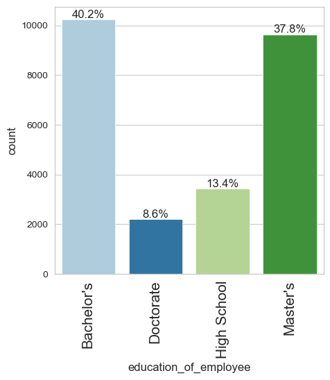

```
Key Insights:
- Bachelor's is the most common education level (40.2%)
- Doctorate is the least common education level (8.6%)
- Total unique education levels: 4
```

```python
# Analyze education of employee
print("Distribution of education_of_employee:")
labeled_barplot(df, 'education_of_employee', perc=True)

# Print insights
edu_dist = df['education_of_employee'].value_counts(normalize=True) * 100
print("Key Insights:")
print(f"- {edu_dist.index[0]} is the most common education level ({edu_dist.iloc[0]:.1f}%)")
print(f"- {edu_dist.index[-1]} is the least common education level ({edu_dist.iloc[-1]:.1f}%)")
print(f"- Total unique education levels: {df['education_of_employee'].nunique()}")
```

#### Observations on region of employment

```
Distribution of region_of_employment:
```

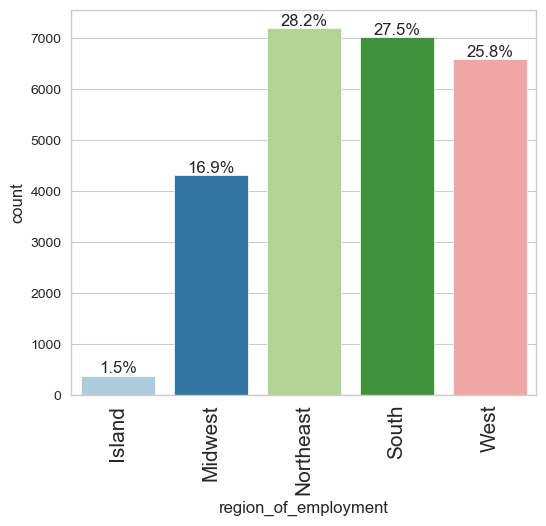

```
Key Insights:
- Northeast is the most popular region (28.2%)
- Island is the least popular region (1.5%)
- Total regions: 5
```

```python
# Analyze region of employment
print("Distribution of region_of_employment:")
labeled_barplot(df, 'region_of_employment', perc=True)

# Print insights
region_dist = df['region_of_employment'].value_counts(normalize=True) * 100
print("Key Insights:")
print(f"- {region_dist.index[0]} is the most popular region ({region_dist.iloc[0]:.1f}%)")
print(f"- {region_dist.index[-1]} is the least popular region ({region_dist.iloc[-1]:.1f}%)")
print(f"- Total regions: {df['region_of_employment'].nunique()}")
```

#### Observations on job experience

```
Distribution of has_job_experience:
```

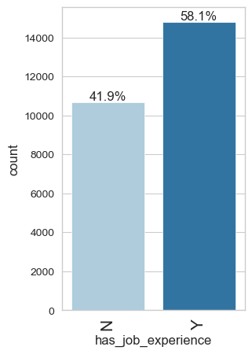

```
Key Insights:
- 58.1% of applicants have job experience
- 41.9% of applicants don't have job experience
```

```python
# Analyze job experience
print("Distribution of has_job_experience:")
labeled_barplot(df, 'has_job_experience', perc=True)

# Print results and observations
exp_dist = df['has_job_experience'].value_counts(normalize=True) * 100
print("Key Insights:")
for exp, pct in exp_dist.items():
    exp_text = "have job experience" if exp == 'Y' else "don't have job experience"
    print(f"- {pct:.1f}% of applicants {exp_text}")
```

#### Observations on case status

```
Distribution of case_status (Target Variable):
```

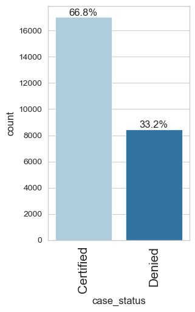

```
Key Insights:
- 66.8% of visa applications are certified
- 33.2% of visa applications are denied

Class Imbalance:
- Ratio of Certified to Denied: 2.01:1
- Dataset shows class imbalance - may need to address during modeling
```

```python
# Analyze case status (target variable)
print("Distribution of case_status (Target Variable):")
labeled_barplot(df, 'case_status', perc=True)

# Print insights
status_dist = df['case_status'].value_counts(normalize=True) * 100
print("Key Insights:")
for status, pct in status_dist.items():
    print(f"- {pct:.1f}% of visa applications are {status.lower()}")

print(f"\nClass Imbalance:")
certified_pct = status_dist['Certified']
denied_pct = status_dist['Denied']
print(f"- Ratio of Certified to Denied: {certified_pct/denied_pct:.2f}:1")
if abs(certified_pct - denied_pct) > 10:
    print(f"- Dataset shows class imbalance - may need to address during modeling")
```

```
Distribution of case_status (Target Variable):
```

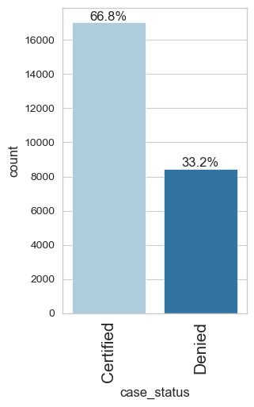

```
Key Insights:
- 66.8% of visa applications are certified
- 33.2% of visa applications are denied
Class Imbalance:
- Ratio of Certified to Denied: 2.01:1
- Dataset shows class imbalance - may need to address during modeling
```

```python
# Analyze case status (target variable)
print("Distribution of case_status (Target Variable):")
labeled_barplot(df, 'case_status', perc=True)

# Print insights
status_dist = df['case_status'].value_counts(normalize=True) * 100
print("Key Insights:")
for status, pct in status_dist.items():
    print(f"- {pct:.1f}% of visa applications are {status.lower()}")

print(f"Class Imbalance:")
certified_pct = status_dist['Certified']
denied_pct = status_dist['Denied']
print(f"- Ratio of Certified to Denied: {certified_pct/denied_pct:.2f}:1")
if abs(certified_pct - denied_pct) > 10:
    print(f"- Dataset shows class imbalance - may need to address during modeling")
```

### Bivariate Analysis

**Creating functions that will help us with further analysis.**

```python
### function to plot distributions wrt target

def distribution_plot_wrt_target(data, predictor, target):

    fig, axs = plt.subplots(2, 2, figsize=(12, 10))

    target_uniq = data[target].unique()

    axs[0, 0].set_title("Distribution of target for target=" + str(target_uniq[0]))
    sns.histplot(
        data=data[data[target] == target_uniq[0]],
        x=predictor,
        kde=True,
        ax=axs[0, 0],
        color="teal",
        stat="density",
    )

    axs[0, 1].set_title("Distribution of target for target=" + str(target_uniq[1]))
    sns.histplot(
        data=data[data[target] == target_uniq[1]],
        x=predictor,
        kde=True,
        ax=axs[0, 1],
        color="orange",
        stat="density",
    )

    axs[1, 0].set_title("Boxplot w.r.t target")
    sns.boxplot(data=data, x=target, y=predictor, ax=axs[1, 0], palette="gist_rainbow")

    axs[1, 1].set_title("Boxplot (without outliers) w.r.t target")
    sns.boxplot(
        data=data,
        x=target,
        y=predictor,
        ax=axs[1, 1],
        showfliers=False,
        palette="gist_rainbow",
    )

    plt.tight_layout()
    plt.show()
```

```python
def stacked_barplot(data, predictor, target):
    """
    Print the category counts and plot a stacked bar chart

    data: dataframe
    predictor: independent variable
    target: target variable
    """
    count = data[predictor].nunique()
    sorter = data[target].value_counts().index[-1]
    tab1 = pd.crosstab(data[predictor], data[target], margins=True).sort_values(
        by=sorter, ascending=False
    )
    print(tab1)
    print("-" * 120)
    tab = pd.crosstab(data[predictor], data[target], normalize="index").sort_values(
        by=sorter, ascending=False
    )
    tab.plot(kind="bar", stacked=True, figsize=(count + 5, 5))
    plt.legend(
        loc="lower left", frameon=False,
    )
    plt.legend(loc="upper left", bbox_to_anchor=(1, 1))
    plt.title(f'Stacked barplot of {predictor} vs {target}')
    plt.tight_layout()
    plt.show()
```

#### Those with higher education may want to travel abroad for a well-paid job. Let's find out if education has any impact on visa certification

```
Analyzing education vs case status:
case_status            Certified  Denied    All
education_of_employee
All                        17018    8462  25480
Bachelor's                  6367    3867  10234
High School                 1164    2256   3420
Master's                    7575    2059   9634
Doctorate                   1912     280   2192
------------------------------------------------------------------------------------------------------------------------
```

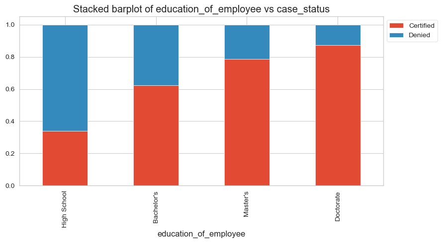

```
Certification rates by education level:
- Doctorate: 87.2%
- Master's: 78.6%
- Bachelor's: 62.2%
- High School: 34.0%
Highest certification rate: Doctorate (87.2%)
Lowest certification rate: High School (34.0%)
```

```python
# Education vs case status analysis
print("Analyzing education vs case status:")
stacked_barplot(df, 'education_of_employee', 'case_status')

# Calculate certification rates by education
edu_cert_rate = df.groupby('education_of_employee')['case_status'].apply(lambda x: (x == 'Certified').mean() * 100)
print("Certification rates by education level:")
for edu, rate in edu_cert_rate.sort_values(ascending=False).items():
    print(f"- {edu}: {rate:.1f}%")

print(f"Highest certification rate: {edu_cert_rate.idxmax()} ({edu_cert_rate.max():.1f}%)")
print(f"Lowest certification rate: {edu_cert_rate.idxmin()} ({edu_cert_rate.min():.1f}%)")
```

#### Lets' similarly check for the continents and find out how the visa status vary across different continents.

```
Analyzing continent vs case status:
case_status    Certified  Denied    All
continent
All                17018    8462  25480
Asia               11012    5849  16861
North America       2037    1255   3292
Europe              2957     775   3732
South America        493     359    852
Africa               397     154    551
Oceania              122      70    192
------------------------------------------------------------------------------------------------------------------------
```

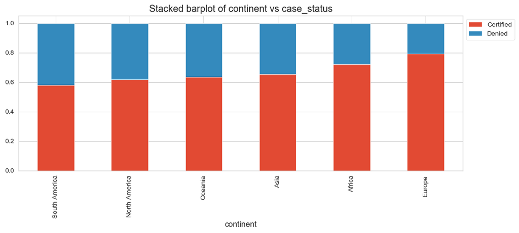

```
Certification rates by continent:
- Europe: 79.2%
- Africa: 72.1%
- Asia: 65.3%
- Oceania: 63.5%
- North America: 61.9%
- South America: 57.9%

Highest certification rate: Europe (79.2%)
Lowest certification rate: South America (57.9%)
```

```python
# Continent vs case status analysis
print("Analyzing continent vs case status:")
stacked_barplot(df, 'continent', 'case_status')

# Calculate certification rates by continent
cont_cert_rate = df.groupby('continent')['case_status'].apply(lambda x: (x == 'Certified').mean() * 100)
print("\nCertification rates by continent:")
for cont, rate in cont_cert_rate.sort_values(ascending=False).items():
    print(f"- {cont}: {rate:.1f}%")

print(f"\nHighest certification rate: {cont_cert_rate.idxmax()} ({cont_cert_rate.max():.1f}%)")
print(f"Lowest certification rate: {cont_cert_rate.idxmin()} ({cont_cert_rate.min():.1f}%)")
```

#### Experienced professionals might look abroad for opportunities to improve their lifestyles and career development. Let's see if having work experience has any influence over visa certification

```
Analyzing job experience vs case status:
case_status         Certified  Denied    All
has_job_experience
All                     17018    8462  25480
N                        5994    4684  10678
Y                       11024    3778  14802
------------------------------------------------------------------------------------------------------------------------
```

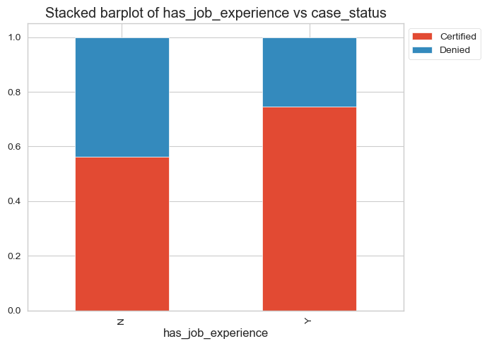

```
Certification rates by job experience:
- Without job experience: 56.1%
- With job experience: 74.5%
```

```python
# Job experience vs case status analysis
print("Analyzing job experience vs case status:")
stacked_barplot(df, 'has_job_experience', 'case_status')

# Calculate certification rates by job experience
exp_cert_rate = df.groupby('has_job_experience')['case_status'].apply(lambda x: (x == 'Certified').mean() * 100)
print("Certification rates by job experience:")
for exp, rate in exp_cert_rate.items():
    exp_text = "With job experience" if exp == 'Y' else "Without job experience"
    print(f"- {exp_text}: {rate:.1f}%")
```

## Additional analysis for requires_job_training

```
==================================================
Analyzing job training requirement vs case status:
case_status            Certified  Denied    All
requires_job_training
All                        17018    8462  25480
N                          15012    7513  22525
Y                           2006     949   2955
------------------------------------------------------------------------------------------------------------------------
```

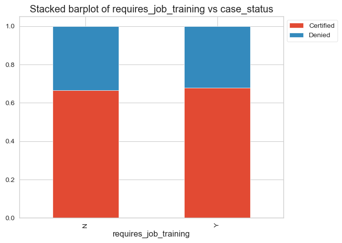

```
Certification rates by job training requirement:
- No training required: 66.6%
- Requires training: 67.9%
```

```python
# Additional analysis for requires_job_training
print("="*50)
print("Analyzing job training requirement vs case status:")
stacked_barplot(df, 'requires_job_training', 'case_status')

train_cert_rate = df.groupby('requires_job_training')['case_status'].apply(lambda x: (x == 'Certified').mean() * 100)
print("Certification rates by job training requirement:")
for train, rate in train_cert_rate.items():
    train_text = "Requires training" if train == 'Y' else "No training required"
    print(f"- {train_text}: {rate:.1f}%")
```

#### Checking if the prevailing wage is similar across all the regions of the US

```
Analyzing prevailing wage across US regions:
```

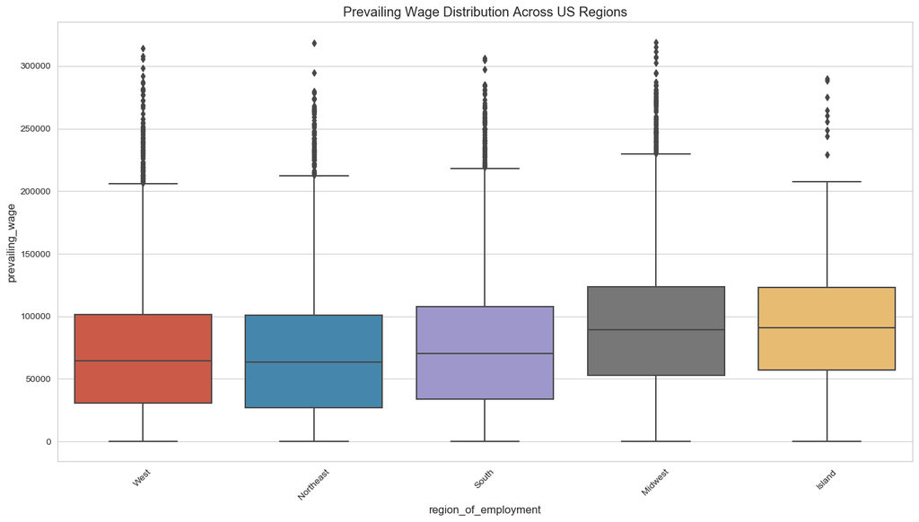

```
Prevailing wage statistics by region:
```

| region_of_employment | mean | median | std |
| --- | --- | --- | --- |
| Island | 91712.75 | 90678.17 | 53836.06 |
| Midwest | 91696.74 | 89153.91 | 54561.01 |
| South | 74040.55 | 70191.52 | 52468.45 |
| West | 69832.63 | 64358.44 | 50638.41 |
| Northeast | 67872.66 | 63276.51 | 51561.44 |

```
Highest average wage region: Island ($91,712.75)
Lowest average wage region: Northeast ($67,872.66)
```

```python
# Region vs prevailing wage analysis
print("Analyzing prevailing wage across US regions:")
plt.figure(figsize=(14, 8))
sns.boxplot(x='region_of_employment', y='prevailing_wage', data=df)
plt.xticks(rotation=45)
plt.title('Prevailing Wage Distribution Across US Regions')
plt.tight_layout()
plt.show()

# Statistical summary by region
wage_by_region = df.groupby('region_of_employment')['prevailing_wage'].agg(['mean', 'median', 'std']).round(2)
wage_by_region = wage_by_region.sort_values('mean', ascending=False)
print("Prevailing wage statistics by region:")
display(wage_by_region)

print(f"Highest average wage region: {wage_by_region.index[0]} (${wage_by_region.iloc[0]['mean']:,.2f})")
print(f"Lowest average wage region: {wage_by_region.index[-1]} (${wage_by_region.iloc[-1]['mean']:,.2f})")
```

#### The US government has established a prevailing wage to protect local talent and foreign workers. Let's analyze the data and see if the visa status changes with the prevailing wage

```
Analyzing prevailing wage vs case status:
```

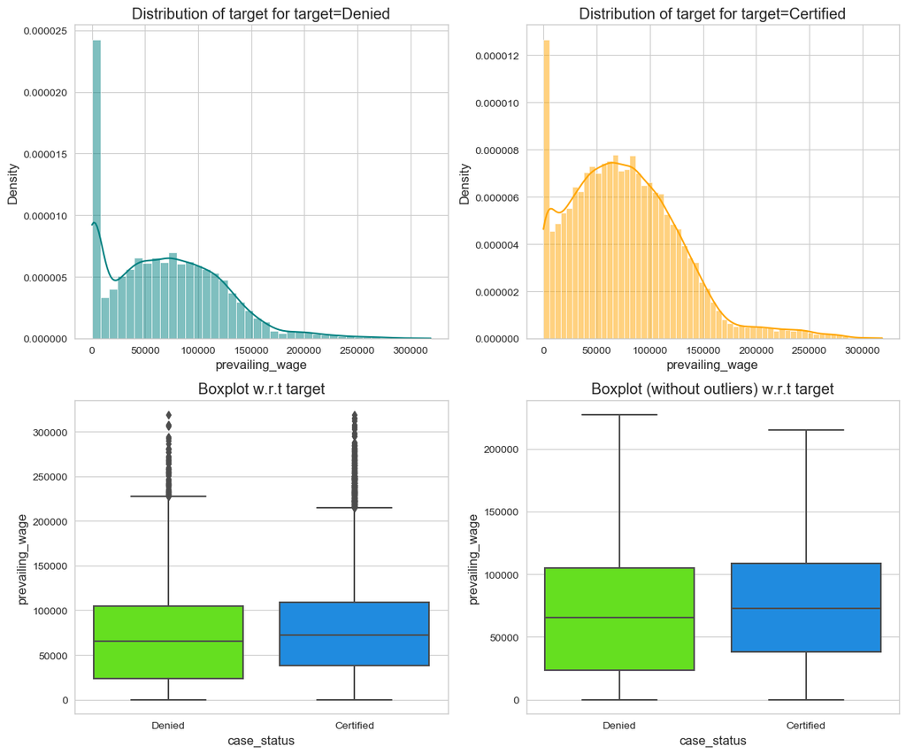

```
Prevailing wage statistics by case status:
```

| case_status | mean | median | std |
| --- | --- | --- | --- |
| Certified | 77293.62 | 72486.27 | 52042.72 |
| Denied | 68748.68 | 65431.46 | 53890.17 |

```
Key Insights:
- Average wage for certified cases: $77,293.62
- Average wage for denied cases: $68,748.68
- Difference: $8,544.94 (+12.4%)
```

```python
# Prevailing wage vs case status analysis
print("Analyzing prevailing wage vs case status:")
distribution_plot_wrt_target(df, 'prevailing_wage', 'case_status')

# Statistical comparison
wage_stats = df.groupby('case_status')['prevailing_wage'].agg(['mean', 'median', 'std']).round(2)
print("Prevailing wage statistics by case status:")
display(wage_stats)

# Calculate difference
certified_mean = wage_stats.loc['Certified', 'mean']
denied_mean = wage_stats.loc['Denied', 'mean']
wage_diff = certified_mean - denied_mean
wage_diff_pct = (wage_diff / denied_mean) * 100

print(f"Key Insights:")
print(f"- Average wage for certified cases: ${certified_mean:,.2f}")
print(f"- Average wage for denied cases: ${denied_mean:,.2f}")
print(f"- Difference: ${wage_diff:,.2f} ({wage_diff_pct:+.1f}%)")
```

#### The prevailing wage has different units (Hourly, Weekly, etc). Let's find out if it has any impact on visa applications getting certified.

```
Analyzing unit of wage vs case status:
case_status   Certified  Denied    All
unit_of_wage
All               17018    8462  25480
Year              16047    6915  22962
Hour                747    1410   2157
Week                169     103    272
Month                55      34     89
------------------------------------------------------------------------------------------------------------------------
```

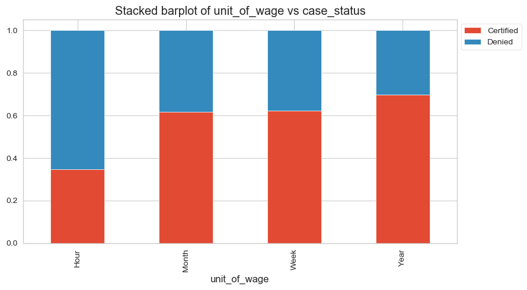

```
Certification rates by wage unit:
- Year: 69.9%
- Week: 62.1%
- Month: 61.8%
- Hour: 34.6%
==================================================
Analyzing full-time position vs case status:
case_status         Certified  Denied    All
full_time_position
All                     17018    8462  25480
Y                       15163    7610  22773
N                        1855     852   2707
------------------------------------------------------------------------------------------------------------------------
```

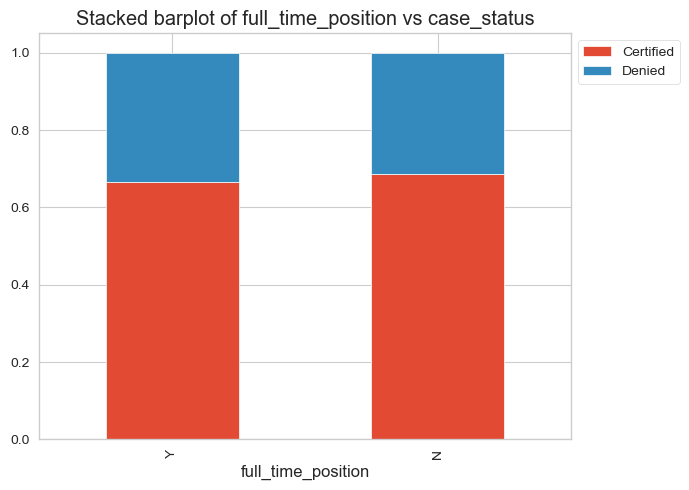

```
Certification rates by position type:
- Part-time: 68.5%
- Full-time: 66.6%
```

```python
# Unit of wage vs case status analysis
print("Analyzing unit of wage vs case status:")
stacked_barplot(df, 'unit_of_wage', 'case_status')

# Calculate certification rates by wage unit
unit_cert_rate = df.groupby('unit_of_wage')['case_status'].apply(lambda x: (x == 'Certified').mean() * 100)
print("Certification rates by wage unit:")
for unit, rate in unit_cert_rate.sort_values(ascending=False).items():
    print(f"- {unit}: {rate:.1f}%")

# Additional analysis: Full-time vs Part-time positions
print("="*50)
print("Analyzing full-time position vs case status:")
stacked_barplot(df, 'full_time_position', 'case_status')

ft_cert_rate = df.groupby('full_time_position')['case_status'].apply(lambda x: (x == 'Certified').mean() * 100)
print("Certification rates by position type:")
for pos, rate in ft_cert_rate.items():
    pos_text = "Full-time" if pos == 'Y' else "Part-time"
    print(f"- {pos_text}: {rate:.1f}%")
```

## Data Pre-processing

### Correlation Analysis

```
Correlation analysis for numerical features:
```

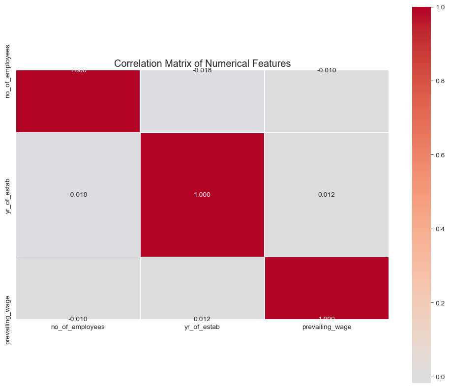

```
Strong correlations (|correlation| > 0.3):
```

```python
# Correlation analysis for numerical features
print("Correlation analysis for numerical features:")
numeric_df = df.select_dtypes(include=['int64', 'float64'])

plt.figure(figsize=(10, 8))
correlation_matrix = numeric_df.corr()
sns.heatmap(correlation_matrix, annot=True, cmap='coolwarm', center=0,
            square=True, linewidths=0.5, fmt='.3f')
plt.title('Correlation Matrix of Numerical Features')
plt.tight_layout()
plt.show()

# Print strong correlations
print("Strong correlations (|correlation| > 0.3):")
for i in range(len(correlation_matrix.columns)):
    for j in range(i+1, len(correlation_matrix.columns)):
        corr_val = correlation_matrix.iloc[i, j]
        if abs(corr_val) > 0.3:
            print(f"- {correlation_matrix.columns[i]} vs {correlation_matrix.columns[j]}: {corr_val:.3f}")
```

### Outlier Check

```python
# Outlier detection for numerical columns
print("Outlier Detection Analysis:")
print("="*50)

numerical_cols = ['no_of_employees', 'yr_of_estab', 'prevailing_wage']

outlier_summary = []

for col in numerical_cols:
    # Calculate IQR method
    q1 = df[col].quantile(0.25)
    q3 = df[col].quantile(0.75)
    iqr = q3 - q1
    lower_bound = q1 - 1.5 * iqr
    upper_bound = q3 + 1.5 * iqr

    # Count outliers
    outliers = df[(df[col] < lower_bound) | (df[col] > upper_bound)]
    outlier_count = len(outliers)
    outlier_percentage = (outlier_count / len(df)) * 100

    print(f"{col}:")
    print(f"- Q1: {q1:.2f}, Q3: {q3:.2f}, IQR: {iqr:.2f}")
    print(f"- Lower bound: {lower_bound:.2f}, Upper bound: {upper_bound:.2f}")
    print(f"- Outliers: {outlier_count} ({outlier_percentage:.2f}%)")

    outlier_summary.append({
        'Column': col,
        'Outlier_Count': outlier_count,
        'Outlier_Percentage': outlier_percentage,
        'Lower_Bound': lower_bound,
        'Upper_Bound': upper_bound
    })

# Create summary dataframe
outlier_df = pd.DataFrame(outlier_summary)
print("Outlier Summary:")
display(outlier_df)
```

```
Outlier Detection Analysis:
==================================================
no_of_employees:
- Q1: 1028.00, Q3: 3504.00, IQR: 2476.00
- Lower bound: -2686.00, Upper bound: 7218.00
- Outliers: 1556 (6.11%)
yr_of_estab:
- Q1: 1976.00, Q3: 2005.00, IQR: 29.00
- Lower bound: 1932.50, Upper bound: 2048.50
- Outliers: 3260 (12.79%)
prevailing_wage:
- Q1: 34015.48, Q3: 107735.51, IQR: 73720.03
- Lower bound: -76564.57, Upper bound: 218315.56
- Outliers: 427 (1.68%)
Outlier Summary:
```

|  | Column | Outlier_Count | Outlier_Percentage | Lower_Bound | Upper_Bound |
| --- | --- | --- | --- | --- | --- |
| 0 | no_of_employees | 1556 | 6.106750 | -2686.00000 | 7218.00000 |
| 1 | yr_of_estab | 3260 | 12.794349 | 1932.50000 | 2048.50000 |
| 2 | prevailing_wage | 427 | 1.675824 | -76564.56875 | 218315.56125 |

### Data Preparation for modeling

```python
# Data preparation for modeling
print("Preparing data for modeling...")
print("="*40)

# Create a copy for modeling
df_model = df.copy()

# Create binary target variable (1 for 'Certified', 0 for 'Denied')
df_model['case_status_binary'] = df_model['case_status'].map({'Certified': 1, 'Denied': 0})
print(f"Target variable encoding: Certified=1, Denied=0")
print(f"Target distribution: {df_model['case_status_binary'].value_counts().to_dict()}")

# Prepare features and target
X = df_model.drop(['case_id', 'case_status', 'case_status_binary'], axis=1)
y = df_model['case_status_binary']

print(f"Feature matrix shape: {X.shape}")
print(f"Target vector shape: {y.shape}")
print(f"Features included: {list(X.columns)}")

# Split data into training and testing sets
X_train, X_test, y_train, y_test = train_test_split(
    X, y, test_size=0.2, random_state=42, stratify=y
)

print(f"Data split completed:")
print(f"Training set shape: X_train {X_train.shape}, y_train {y_train.shape}")
print(f"Testing set shape: X_test {X_test.shape}, y_test {y_test.shape}")

# Check class distribution in splits
train_dist = y_train.value_counts(normalize=True) * 100
test_dist = y_test.value_counts(normalize=True) * 100

print(f"Class distribution in training set:")
print(f"- Certified: {train_dist[1]:.1f}%, Denied: {train_dist[0]:.1f}%")
print(f"Class distribution in testing set:")
print(f"- Certified: {test_dist[1]:.1f}%, Denied: {test_dist[0]:.1f}%")
```

```
Preparing data for modeling...
========================================
Target variable encoding: Certified=1, Denied=0
Target distribution: {1: 17018, 0: 8462}
Feature matrix shape: (25480, 10)
Target vector shape: (25480,)
Features included: ['continent', 'education_of_employee', 'has_job_experience', 'requires_job_training', 'no_of_employees', 'yr_of_estab', 'region_of_employment', 'prevailing_wage', 'unit_of_wage', 'full_time_position']
Data split completed:
Training set shape: X_train (20384, 10), y_train (20384,)
Testing set shape: X_test (5096, 10), y_test (5096,)
Class distribution in training set:
- Certified: 66.8%, Denied: 33.2%
Class distribution in testing set:
- Certified: 66.8%, Denied: 33.2%
```

## Model Building

### Model Evaluation Criterion

```python
# defining a function to compute different metrics to check performance of a classification model built using sklearn


def model_performance_classification_sklearn(model, predictors, target):
    """
    Function to compute different metrics to check classification model performance

    model: classifier
    predictors: independent variables
    target: dependent variable
    """

    # predicting using the independent variables
    pred = model.predict(predictors)

    acc = accuracy_score(target, pred)  # to compute Accuracy
    recall = recall_score(target, pred)  # to compute Recall
    precision = precision_score(target, pred)  # to compute Precision
    f1 = f1_score(target, pred)  # to compute F1-score

    # creating a dataframe of metrics
    df_perf = pd.DataFrame(
        {"Accuracy": acc, "Recall": recall, "Precision": precision, "F1": f1,},
        index=[0],
    )

    return df_perf
```

```python
def confusion_matrix_sklearn(model, predictors, target):
    """
    To plot the confusion_matrix with percentages

    model: classifier
    predictors: independent variables
    target: dependent variable
    """
    y_pred = model.predict(predictors)
    cm = confusion_matrix(target, y_pred)
    labels = np.asarray(
        [
            ["{0:0.0f}".format(item) + "\n{0:.2%}".format(item / cm.flatten().sum())]
            for item in cm.flatten()
        ]
    ).reshape(2, 2)

    plt.figure(figsize=(6, 4))
    sns.heatmap(cm, annot=labels, fmt="")
    plt.ylabel("True label")
    plt.xlabel("Predicted label")
    plt.title('Confusion Matrix')
    plt.show()
```

#### Defining scorer to be used for cross-validation and hyperparameter tuning

**We are now done with pre-processing and evaluation criterion, so let's start building the model.**

```python
# Define scoring metrics for cross-validation and hyperparameter tuning
from sklearn.metrics import make_scorer

# Primary scorer will be F1-score as it balances precision and recall
# This is important for imbalanced datasets
scoring = {
    'accuracy': 'accuracy',
    'precision': 'precision',
    'recall': 'recall',
    'f1': 'f1',
    'roc_auc': 'roc_auc'
}

# Primary scorer for hyperparameter tuning
primary_scorer = 'f1'

print(f"Scoring metrics defined: {list(scoring.keys())}")
print(f"Primary scorer for hyperparameter tuning: {primary_scorer}")
print("Ration for F1 as primary scorer:")
print("- F1-score balances precision and recall")
print("- Important for imbalanced datasets like visa approvals")
print("- Helps avoid models that are biased towards majority class")
```

```
Scoring metrics defined: ['accuracy', 'precision', 'recall', 'f1', 'roc_auc']
Primary scorer for hyperparameter tuning: f1
Ration for F1 as primary scorer:
- F1-score balances precision and recall
- Important for imbalanced datasets like visa approvals
- Helps avoid models that are biased towards majority class
```

### Model building with original data

```python
# Create preprocessor for the models (fixed version)
from sklearn.preprocessing import StandardScaler, OneHotEncoder
from sklearn.compose import ColumnTransformer

# Identify categorical and numerical columns for preprocessing
categorical_features = ['continent', 'education_of_employee', 'has_job_experience',
                       'requires_job_training', 'region_of_employment', 'unit_of_wage',
                       'full_time_position']
numerical_features = ['no_of_employees', 'yr_of_estab', 'prevailing_wage']

print(f"Categorical features: {categorical_features}")
print(f"Numerical features: {numerical_features}")

# Create preprocessor with compatible parameters
preprocessor = ColumnTransformer(
    transformers=[
        ('num', StandardScaler(), numerical_features),
        ('cat', OneHotEncoder(drop='first'), categorical_features)  # Removed handle_unknown parameter
    ]
)

print("Preprocessor created successfully!")
```

```
Categorical features: ['continent', 'education_of_employee', 'has_job_experience', 'requires_job_training', 'region_of_employment', 'unit_of_wage', 'full_time_position']
Numerical features: ['no_of_employees', 'yr_of_estab', 'prevailing_wage']
Preprocessor created successfully!
```

```
============================================================
MODEL BUILDING WITH ORIGINAL DATA
============================================================
========================================
Training Decision Tree...
========================================
Decision Tree performance on training data:
```

|  | Accuracy | Recall | Precision | F1 |
| --- | --- | --- | --- | --- |
| 0 | 1.0 | 1.0 | 1.0 | 1.0 |

```
Decision Tree performance on testing data:
```

|  | Accuracy | Recall | Precision | F1 |
| --- | --- | --- | --- | --- |
| 0 | 0.650706 | 0.734136 | 0.740664 | 0.737386 |

```
Confusion Matrix for Decision Tree:
```

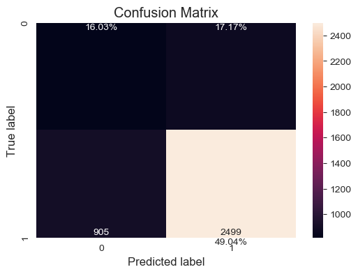

```
========================================
Training Random Forest...
========================================
Random Forest performance on training data:
```

|  | Accuracy | Recall | Precision | F1 |
| --- | --- | --- | --- | --- |
| 0 | 0.999951 | 1.0 | 0.999927 | 0.999963 |

```
Random Forest performance on testing data:
```

|  | Accuracy | Recall | Precision | F1 |
| --- | --- | --- | --- | --- |
| 0 | 0.720369 | 0.836663 | 0.766209 | 0.799888 |

```
Confusion Matrix for Random Forest:
```

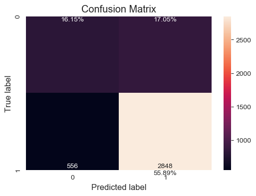

```
========================================
Training Bagging Classifier...
========================================
Bagging Classifier performance on training data:
```

|  | Accuracy | Recall | Precision | F1 |
| --- | --- | --- | --- | --- |
| 0 | 0.999951 | 1.0 | 0.999927 | 0.999963 |

```
Bagging Classifier performance on testing data:
```

|  | Accuracy | Recall | Precision | F1 |
| --- | --- | --- | --- | --- |
| 0 | 0.718995 | 0.833137 | 0.766486 | 0.798423 |

```
Confusion Matrix for Bagging Classifier:
```

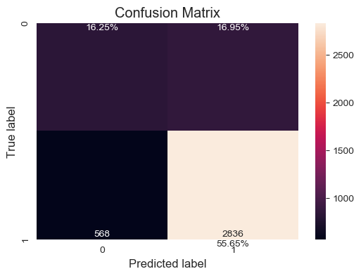

```
========================================
Training AdaBoost...
========================================
AdaBoost performance on training data:
```

|  | Accuracy | Recall | Precision | F1 |
| --- | --- | --- | --- | --- |
| 0 | 0.74009 | 0.887028 | 0.762566 | 0.820102 |

```
AdaBoost performance on testing data:
```

|  | Accuracy | Recall | Precision | F1 |
| --- | --- | --- | --- | --- |
| 0 | 0.724686 | 0.878085 | 0.751572 | 0.809917 |

```
Confusion Matrix for AdaBoost:
```

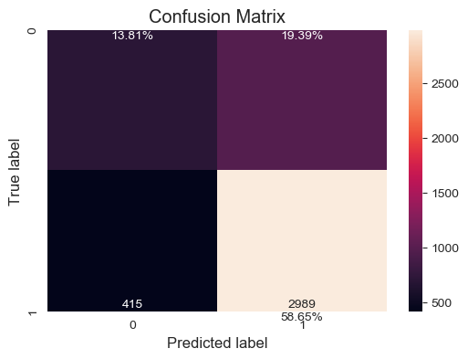

```
========================================
Training Gradient Boosting...
========================================
Gradient Boosting performance on training data:
```

|  | Accuracy | Recall | Precision | F1 |
| --- | --- | --- | --- | --- |
| 0 | 0.756623 | 0.875937 | 0.784694 | 0.827809 |

```
Gradient Boosting performance on testing data:
```

|  | Accuracy | Recall | Precision | F1 |
| --- | --- | --- | --- | --- |
| 0 | 0.741562 | 0.872503 | 0.770828 | 0.81852 |

```
Confusion Matrix for Gradient Boosting:
```

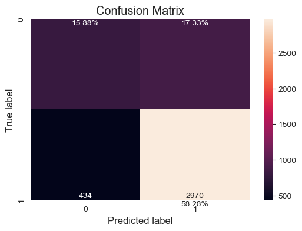

```
========================================
Training XGBoost...
========================================
XGBoost performance on training data:
```

|  | Accuracy | Recall | Precision | F1 |
| --- | --- | --- | --- | --- |
| 0 | 0.830455 | 0.925665 | 0.837565 | 0.879414 |

```
XGBoost performance on testing data:
```

|  | Accuracy | Recall | Precision | F1 |
| --- | --- | --- | --- | --- |
| 0 | 0.734105 | 0.861633 | 0.768405 | 0.812353 |

```
Confusion Matrix for XGBoost:
```

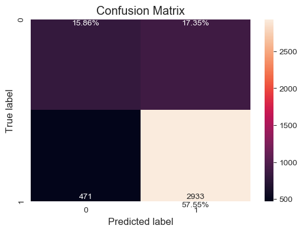

```
og data models training completed!
```

```python
# Model building with original data
print("="*60)
print("MODEL BUILDING WITH ORIGINAL DATA")
print("="*60)

# Define models to train
models = {
    'Decision Tree': DecisionTreeClassifier(random_state=42),
    'Random Forest': RandomForestClassifier(random_state=42, n_estimators=100),
    'Bagging Classifier': BaggingClassifier(random_state=42, n_estimators=100),
    'AdaBoost': AdaBoostClassifier(random_state=42, n_estimators=100),
    'Gradient Boosting': GradientBoostingClassifier(random_state=42, n_estimators=100)
}

# Add XGBoost since it's available
if XGBOOST_AVAILABLE:
    models['XGBoost'] = xgb.XGBClassifier(random_state=42, eval_metric='logloss')

# Store model performances and trained models
original_performances = {}
original_models = {}

# Train and evaluate each model
for name, model in models.items():
    print(f"{'='*40}")
    print(f"Training {name}...")
    print(f"{'='*40}")

    # Create pipeline with preprocessing and model
    pipeline = Pipeline(steps=[
        ('preprocessor', preprocessor),
        ('model', model)
    ])

    # Fit the pipeline
    pipeline.fit(X_train, y_train)

    # Evaluate on training data
    train_perf = model_performance_classification_sklearn(pipeline, X_train, y_train)
    print(f"{name} performance on training data:")
    display(train_perf)

    # Evaluate on testing data
    test_perf = model_performance_classification_sklearn(pipeline, X_test, y_test)
    print(f"{name} performance on testing data:")
    display(test_perf)

    # Plot confusion matrix
    print(f"Confusion Matrix for {name}:")
    confusion_matrix_sklearn(pipeline, X_test, y_test)

    # Store performances and trained model
    original_performances[name] = {
        'train': train_perf,
        'test': test_perf
    }
    original_models[name] = pipeline

print("og data models training completed!")
```

### Model Building with oversampled data

```python
# Model building with oversampled data
print( "="*60)
print("MODEL BUILDING WITH OVERSAMPLED DATA")
print("="*60)

# Manual oversampling - duplicate minority class samples
print("Applying oversampling technique...")

# First, let's preprocess the training data
X_train_transformed = preprocessor.fit_transform(X_train)

# Find minority and majority classes
minority_class = y_train.value_counts().idxmin()
majority_class = y_train.value_counts().idxmax()

print(f"Minority class: {minority_class}, Majority class: {majority_class}")

# Get boolean masks for each class
minority_mask = y_train == minority_class
majority_mask = y_train == majority_class

# Get the actual indices in the training set
minority_train_indices = np.where(minority_mask)[0]
majority_train_indices = np.where(majority_mask)[0]

# Calculate how many samples to add
majority_count = len(majority_train_indices)
minority_count = len(minority_train_indices)
samples_to_add = majority_count - minority_count

print(f"Original counts - Majority: {majority_count}, Minority: {minority_count}")
print(f"Samples to add for balancing: {samples_to_add}")

# Randomly sample from minority class with replacement
np.random.seed(42)
additional_minority_indices = np.random.choice(
    minority_train_indices,
    size=samples_to_add,
    replace=True
)

# Combine all indices
all_indices = np.concatenate([
    majority_train_indices,
    minority_train_indices,
    additional_minority_indices
])

# Create oversampled dataset
X_train_oversampled = X_train_transformed[all_indices]
y_train_oversampled = y_train.iloc[all_indices].values

print(f"After oversampling:")
print(f"Original training set shape: {pd.Series(y_train).value_counts()}")
print(f"Oversampled training set shape: {pd.Series(y_train_oversampled).value_counts()}")

print("\nOversampling completed!")
```

```
============================================================
MODEL BUILDING WITH OVERSAMPLED DATA
============================================================
Applying oversampling technique...
Minority class: 0, Majority class: 1
Original counts - Majority: 13614, Minority: 6770
Samples to add for balancing: 6844
After oversampling:
Original training set shape: 1    13614
0     6770
Name: case_status_binary, dtype: int64
Oversampled training set shape: 1    13614
0    13614
dtype: int64

Oversampling completed!
```

### Model Building with oversample data

```python
# Train models on oversampled data
oversampled_performances = {}
oversampled_models = {}

# Train and evaluate each model with oversampled data
for name, model in models.items():
    print(f"{'='*40}")
    print(f"Training {name} with oversampled data...")
    print(f"{'='*40}")

    # Create a new instance of the model to avoid conflicts
    if name == 'Decision Tree':
        model_instance = DecisionTreeClassifier(random_state=42)
    elif name == 'Random Forest':
        model_instance = RandomForestClassifier(random_state=42, n_estimators=100)
    elif name == 'Bagging Classifier':
        model_instance = BaggingClassifier(random_state=42, n_estimators=100)
    elif name == 'AdaBoost':
        model_instance = AdaBoostClassifier(random_state=42, n_estimators=100)
    elif name == 'Gradient Boosting':
        model_instance = GradientBoostingClassifier(random_state=42, n_estimators=100)
    elif name == 'XGBoost' and XGBOOST_AVAILABLE:
        model_instance = xgb.XGBClassifier(random_state=42, eval_metric='logloss')

    # Fit the model directly on oversampled data (already preprocessed)
    model_instance.fit(X_train_oversampled, y_train_oversampled)

    # Evaluate on training data
    train_pred = model_instance.predict(X_train_oversampled)
    train_acc = accuracy_score(y_train_oversampled, train_pred)
    train_precision = precision_score(y_train_oversampled, train_pred)
    train_recall = recall_score(y_train_oversampled, train_pred)
    train_f1 = f1_score(y_train_oversampled, train_pred)

    train_perf = pd.DataFrame({
        'Accuracy': [train_acc],
        'Precision': [train_precision],
        'Recall': [train_recall],
        'F1': [train_f1]
    })

    print(f"{name} performance on oversampled training data:")
    display(train_perf)

    # Evaluate on testing data (need to preprocess test data)
    X_test_transformed = preprocessor.transform(X_test)
    test_pred = model_instance.predict(X_test_transformed)
    test_acc = accuracy_score(y_test, test_pred)
    test_precision = precision_score(y_test, test_pred)
    test_recall = recall_score(y_test, test_pred)
    test_f1 = f1_score(y_test, test_pred)

    test_perf = pd.DataFrame({
        'Accuracy': [test_acc],
        'Precision': [test_precision],
        'Recall': [test_recall],
        'F1': [test_f1]
    })

    print(f"\n{name} performance on testing data (model trained on oversampled data):")
    display(test_perf)

    # Store performances and trained model
    oversampled_performances[name] = {
        'train': train_perf,
        'test': test_perf
    }
    oversampled_models[name] = model_instance

print("Oversampled data models training completed!")
```

```
========================================
Training Decision Tree with oversampled data...
========================================
Decision Tree performance on oversampled training data:
```

|  | Accuracy | Precision | Recall | F1 |
| --- | --- | --- | --- | --- |
| 0 | 1.0 | 1.0 | 1.0 | 1.0 |

```
Decision Tree performance on testing data (model trained on oversampled data):
```

|  | Accuracy | Precision | Recall | F1 |
| --- | --- | --- | --- | --- |
| 0 | 0.657771 | 0.741139 | 0.749412 | 0.745253 |

```
========================================
Training Random Forest with oversampled data...
========================================
Random Forest performance on oversampled training data:
```

|  | Accuracy | Precision | Recall | F1 |
| --- | --- | --- | --- | --- |
| 0 | 1.0 | 1.0 | 1.0 | 1.0 |

```
Random Forest performance on testing data (model trained on oversampled data):
```

|  | Accuracy | Precision | Recall | F1 |
| --- | --- | --- | --- | --- |
| 0 | 0.703689 | 0.776416 | 0.781434 | 0.778917 |

```
========================================
Training Bagging Classifier with oversampled data...
========================================
Bagging Classifier performance on oversampled training data:
```

|  | Accuracy | Precision | Recall | F1 |
| --- | --- | --- | --- | --- |
| 0 | 1.0 | 1.0 | 1.0 | 1.0 |

```
Bagging Classifier performance on testing data (model trained on oversampled data):
```

|  | Accuracy | Precision | Recall | F1 |
| --- | --- | --- | --- | --- |
| 0 | 0.709772 | 0.779553 | 0.788484 | 0.783993 |

```
========================================
Training AdaBoost with oversampled data...
========================================
AdaBoost performance on oversampled training data:
```

|  | Accuracy | Precision | Recall | F1 |
| --- | --- | --- | --- | --- |
| 0 | 0.704091 | 0.694859 | 0.72778 | 0.710939 |

```
AdaBoost performance on testing data (model trained on oversampled data):
```

|  | Accuracy | Precision | Recall | F1 |
| --- | --- | --- | --- | --- |
| 0 | 0.69113 | 0.80298 | 0.712397 | 0.754981 |

```
========================================
Training Gradient Boosting with oversampled data...
========================================
Gradient Boosting performance on oversampled training data:
```

|  | Accuracy | Precision | Recall | F1 |
| --- | --- | --- | --- | --- |
| 0 | 0.718599 | 0.713272 | 0.731086 | 0.722069 |

```
Gradient Boosting performance on testing data (model trained on oversampled data):
```

|  | Accuracy | Precision | Recall | F1 |
| --- | --- | --- | --- | --- |
| 0 | 0.701727 | 0.815261 | 0.715629 | 0.762203 |

```
========================================
Training XGBoost with oversampled data...
========================================
XGBoost performance on oversampled training data:
```

|  | Accuracy | Precision | Recall | F1 |
| --- | --- | --- | --- | --- |
| 0 | 0.833186 | 0.835702 | 0.82944 | 0.832559 |

```
XGBoost performance on testing data (model trained on oversampled data):
```

|  | Accuracy | Precision | Recall | F1 |
| --- | --- | --- | --- | --- |
| 0 | 0.709772 | 0.799006 | 0.755582 | 0.776687 |

```
Oversampled data models training completed!
```

### Model Building with undersampled data

```python
# Model building with undersampled data
print("="*60)
print("MODEL BUILDING WITH UNDERSAMPLED DATA")
print("="*60)

# Manual undersampling - reduce majority class samples
print("Applying undersampling technique...")

# Use the same preprocessed training data
X_train_transformed = preprocessor.fit_transform(X_train)

# Find minority and majority classes
minority_class = y_train.value_counts().idxmin()
majority_class = y_train.value_counts().idxmax()

# Get boolean masks for each class
minority_mask = y_train == minority_class
majority_mask = y_train == majority_class

# Get the actual indices in the training set
minority_train_indices = np.where(minority_mask)[0]
majority_train_indices = np.where(majority_mask)[0]

# Calculate how many majority samples to keep
minority_count = len(minority_train_indices)
majority_count = len(majority_train_indices)

print(f"Original counts - Majority: {majority_count}, Minority: {minority_count}")
print(f"Undersampling majority class to: {minority_count}")

# Randomly sample from majority class without replacement
np.random.seed(42)
sampled_majority_indices = np.random.choice(
    majority_train_indices,
    size=minority_count,
    replace=False
)

# Combine minority and sampled majority indices
all_indices = np.concatenate([minority_train_indices, sampled_majority_indices])

# Create undersampled dataset
X_train_undersampled = X_train_transformed[all_indices]
y_train_undersampled = y_train.iloc[all_indices].values

print(f"After undersampling:")
print(f"Original training set shape: {pd.Series(y_train).value_counts()}")
print(f"Undersampled training set shape: {pd.Series(y_train_undersampled).value_counts()}")

print("Undersampling completed!")
```

```
============================================================
MODEL BUILDING WITH UNDERSAMPLED DATA
============================================================
Applying undersampling technique...
Original counts - Majority: 13614, Minority: 6770
Undersampling majority class to: 6770
After undersampling:
Original training set shape: 1    13614
0     6770
Name: case_status_binary, dtype: int64
Undersampled training set shape: 0    6770
1    6770
dtype: int64
Undersampling completed!
```

```python
# Train models on undersampled data
undersampled_performances = {}
undersampled_models = {}

# Train and evaluate each model with undersampled data
for name, model in models.items():
    print(f"{'='*40}")
    print(f"Training {name} with undersampled data...")
    print(f"{'='*40}")

    # Create a new instance of the model to avoid conflicts
    if name == 'Decision Tree':
        model_instance = DecisionTreeClassifier(random_state=42)
    elif name == 'Random Forest':
        model_instance = RandomForestClassifier(random_state=42, n_estimators=100)
    elif name == 'Bagging Classifier':
        model_instance = BaggingClassifier(random_state=42, n_estimators=100)
    elif name == 'AdaBoost':
        model_instance = AdaBoostClassifier(random_state=42, n_estimators=100)
    elif name == 'Gradient Boosting':
        model_instance = GradientBoostingClassifier(random_state=42, n_estimators=100)
    elif name == 'XGBoost' and XGBOOST_AVAILABLE:
        model_instance = xgb.XGBClassifier(random_state=42, eval_metric='logloss')

    # Fit the model directly on undersampled data (already preprocessed)
    model_instance.fit(X_train_undersampled, y_train_undersampled)

    # Evaluate on training data
    train_pred = model_instance.predict(X_train_undersampled)
    train_acc = accuracy_score(y_train_undersampled, train_pred)
    train_precision = precision_score(y_train_undersampled, train_pred)
    train_recall = recall_score(y_train_undersampled, train_pred)
    train_f1 = f1_score(y_train_undersampled, train_pred)

    train_perf = pd.DataFrame({
        'Accuracy': [train_acc],
        'Precision': [train_precision],
        'Recall': [train_recall],
        'F1': [train_f1]
    })

    print(f"\n{name} performance on undersampled training data:")
    display(train_perf)

    # Evaluate on testing data (need to preprocess test data)
    X_test_transformed = preprocessor.transform(X_test)
    test_pred = model_instance.predict(X_test_transformed)
    test_acc = accuracy_score(y_test, test_pred)
    test_precision = precision_score(y_test, test_pred)
    test_recall = recall_score(y_test, test_pred)
    test_f1 = f1_score(y_test, test_pred)

    test_perf = pd.DataFrame({
        'Accuracy': [test_acc],
        'Precision': [test_precision],
        'Recall': [test_recall],
        'F1': [test_f1]
    })

    print(f"\n{name} performance on testing data (model trained on undersampled data):")
    display(test_perf)

    # Store performances and trained model
    undersampled_performances[name] = {
        'train': train_perf,
        'test': test_perf
    }
    undersampled_models[name] = model_instance

print("Undersampled data models training completed!")
```

```
========================================
Training Decision Tree with undersampled data...
========================================

Decision Tree performance on undersampled training data:
```

|  | Accuracy | Precision | Recall | F1 |
| --- | --- | --- | --- | --- |
| 0 | 1.0 | 1.0 | 1.0 | 1.0 |

```
Decision Tree performance on testing data (model trained on undersampled data):
```

|  | Accuracy | Precision | Recall | F1 |
| --- | --- | --- | --- | --- |
| 0 | 0.61303 | 0.761314 | 0.612808 | 0.679036 |

```
========================================
Training Random Forest with undersampled data...
========================================

Random Forest performance on undersampled training data:
```

|  | Accuracy | Precision | Recall | F1 |
| --- | --- | --- | --- | --- |
| 0 | 1.0 | 1.0 | 1.0 | 1.0 |

```
Random Forest performance on testing data (model trained on undersampled data):
```

|  | Accuracy | Precision | Recall | F1 |
| --- | --- | --- | --- | --- |
| 0 | 0.678375 | 0.813499 | 0.672738 | 0.736453 |

```
========================================
Training Bagging Classifier with undersampled data...
========================================

Bagging Classifier performance on undersampled training data:
```

|  | Accuracy | Precision | Recall | F1 |
| --- | --- | --- | --- | --- |
| 0 | 1.0 | 1.0 | 1.0 | 1.0 |

```
Bagging Classifier performance on testing data (model trained on undersampled data):
```

|  | Accuracy | Precision | Recall | F1 |
| --- | --- | --- | --- | --- |
| 0 | 0.678964 | 0.816392 | 0.670094 | 0.736044 |

```
========================================
Training AdaBoost with undersampled data...
========================================

AdaBoost performance on undersampled training data:
```

|  | Accuracy | Precision | Recall | F1 |
| --- | --- | --- | --- | --- |
| 0 | 0.703471 | 0.693551 | 0.729099 | 0.710881 |

```
AdaBoost performance on testing data (model trained on undersampled data):
```

|  | Accuracy | Precision | Recall | F1 |
| --- | --- | --- | --- | --- |
| 0 | 0.691719 | 0.802575 | 0.71416 | 0.75579 |

```
========================================
Training Gradient Boosting with undersampled data...
========================================

Gradient Boosting performance on undersampled training data:
```

|  | Accuracy | Precision | Recall | F1 |
| --- | --- | --- | --- | --- |
| 0 | 0.720089 | 0.712493 | 0.737962 | 0.725004 |

```
Gradient Boosting performance on testing data (model trained on undersampled data):
```

|  | Accuracy | Precision | Recall | F1 |
| --- | --- | --- | --- | --- |
| 0 | 0.700353 | 0.811484 | 0.718273 | 0.762038 |

```
========================================
Training XGBoost with undersampled data...
========================================

XGBoost performance on undersampled training data:
```

|  | Accuracy | Precision | Recall | F1 |
| --- | --- | --- | --- | --- |
| 0 | 0.84579 | 0.847639 | 0.843131 | 0.845379 |

```
XGBoost performance on testing data (model trained on undersampled data):
```

|  | Accuracy | Precision | Recall | F1 |
| --- | --- | --- | --- | --- |
| 0 | 0.68073 | 0.809906 | 0.682139 | 0.740552 |

```
Undersampled data models training completed!
```

## Hyperparameter Tuning

```python
# Hyperparameter Tuning
print( "="*60)
print("HYPERPARAMETER TUNING")
print("="*60)

# Compare all models across all sampling methods
print("Comparing F1 scores across all sampling methods:")
all_models_comparison = pd.DataFrame({
    'Original': {model: perf['test'].iloc[0]['F1'] for model, perf in original_performances.items()},
    'Oversampled': {model: perf['test'].iloc[0]['F1'] for model, perf in oversampled_performances.items()},
    'Undersampled': {model: perf['test'].iloc[0]['F1'] for model, perf in undersampled_performances.items()}
})

display(all_models_comparison)

# Select top 3 models for hyperparameter tuning based on best F1 scores
# Flatten the comparison and get top 3
all_scores = []
for sampling_method in all_models_comparison.columns:
    for model_name in all_models_comparison.index:
        score = all_models_comparison.loc[model_name, sampling_method]
        all_scores.append((model_name, sampling_method, score))

# Sort by F1 score and get top 3
all_scores.sort(key=lambda x: x[2], reverse=True)
top_3_models = all_scores[:3]

print(f"Top 3 models selected for hyperparameter tuning:")
for i, (model_name, sampling_method, f1_score) in enumerate(top_3_models, 1):
    print(f"{i}. {model_name} ({sampling_method}): F1 = {f1_score:.4f}")

# Define parameter grids for hyperparameter tuning
param_grids = {
    'Random Forest': {
        'n_estimators': [50, 100, 200],
        'max_depth': [None, 10, 20],
        'min_samples_split': [2, 5, 10]
    },
    'Gradient Boosting': {
        'n_estimators': [50, 100, 200],
        'learning_rate': [0.01, 0.1, 0.2],
        'max_depth': [3, 5, 7]
    },
    'AdaBoost': {
        'n_estimators': [50, 100, 200],
        'learning_rate': [0.01, 0.1, 1.0]
    },
    'Decision Tree': {
        'max_depth': [None, 5, 10, 15, 20],
        'min_samples_split': [2, 5, 10, 20],
        'min_samples_leaf': [1, 2, 5, 10]
    },
    'Bagging Classifier': {
        'n_estimators': [50, 100, 200],
        'max_samples': [0.5, 0.7, 1.0]
    }
}

if XGBOOST_AVAILABLE:
    param_grids['XGBoost'] = {
        'n_estimators': [50, 100, 200],
        'learning_rate': [0.01, 0.1, 0.2],
        'max_depth': [3, 5, 7]
    }

print(f"Parameter grids defined for {len(param_grids)} models")
```

```
============================================================
HYPERPARAMETER TUNING
============================================================
Comparing F1 scores across all sampling methods:
```

|  | Original | Oversampled | Undersampled |
| --- | --- | --- | --- |
| Decision Tree | 0.737386 | 0.745253 | 0.679036 |
| Random Forest | 0.799888 | 0.778917 | 0.736453 |
| Bagging Classifier | 0.798423 | 0.783993 | 0.736044 |
| AdaBoost | 0.809917 | 0.754981 | 0.755790 |
| Gradient Boosting | 0.818520 | 0.762203 | 0.762038 |
| XGBoost | 0.812353 | 0.776687 | 0.740552 |

```
Top 3 models selected for hyperparameter tuning:
1. Gradient Boosting (Original): F1 = 0.8185
2. XGBoost (Original): F1 = 0.8124
3. AdaBoost (Original): F1 = 0.8099
Parameter grids defined for 6 models
```